# homework 3: BMB’s version

Published

12 Nov 2024

```r
library(tidyverse)
library(ggplot2); theme_set(theme_bw())
library(nlme)
library(lmerTest)
library(glmmTMB)
library(broom.mixed)
library(buildmer)
library(car) ## for ellipse()
```

```r
data("ScotsSec", package = "mlmRev")
m_full <- lmer(attain ~ verbal + sex + social +
                   (1 + verbal + sex + social | primary),
               data = ScotsSec)
```

```
boundary (singular) fit: see help('isSingular')
```

Out of curiosity, I’m going to see what the `buildmer` package does with this model:

```r
m_b <- buildmer(attain ~ verbal + sex + social +
                   (1 + verbal + sex + social | primary),
                data = ScotsSec)
```

```
Determining predictor order
```

```
Fitting via lm: attain ~ 1
```

```
Currently evaluating LRT for: verbal, sex, social
```

```
Fitting via lm: attain ~ 1 + verbal
```

```
Fitting via lm: attain ~ 1 + sex
```

```
Fitting via lm: attain ~ 1 + social
```

```
Updating formula: attain ~ 1 + verbal
```

```
Currently evaluating LRT for: sex, social
```

```
Fitting via lm: attain ~ 1 + verbal + sex
```

```
Fitting via lm: attain ~ 1 + verbal + social
```

```
Updating formula: attain ~ 1 + verbal + social
```

```
Currently evaluating LRT for: sex
```

```
Fitting via lm: attain ~ 1 + verbal + social + sex
```

```
Updating formula: attain ~ 1 + verbal + social + sex
```

```
Fitting via gam, with REML: attain ~ 1 + verbal + social + sex
```

```
Currently evaluating LRT for: 1 | primary
```

```
Fitting via lmer, with REML: attain ~ 1 + verbal + social + sex + (1 |
    primary)
```

```
Updating formula: attain ~ 1 + verbal + social + sex + (1 | primary)
```

```
Currently evaluating LRT for: verbal | primary, sex | primary, social |
    primary
```

```
Fitting via lmer, with REML: attain ~ 1 + verbal + social + sex + (1 +
    verbal | primary)
```

```
boundary (singular) fit: see help('isSingular')
```

```
Fitting via lmer, with REML: attain ~ 1 + verbal + social + sex + (1 +
    sex | primary)
```

```
Fitting via lmer, with REML: attain ~ 1 + verbal + social + sex + (1 +
    social | primary)
```

```
Updating formula: attain ~ 1 + verbal + social + sex + (1 + sex |
    primary)
```

```
Currently evaluating LRT for: verbal | primary, social | primary
```

```
Fitting via lmer, with REML: attain ~ 1 + verbal + social + sex + (1 +
    sex + verbal | primary)
```

```
boundary (singular) fit: see help('isSingular')
```

```
Fitting via lmer, with REML: attain ~ 1 + verbal + social + sex + (1 +
    sex + social | primary)
```

```
Ending the ordering procedure due to having reached the maximal
    feasible model - all higher models failed to converge. The types of
    convergence failure are: Singular fit lme4 reports not having
    converged (-1)
```

```
Fitting ML and REML reference models
```

```
Fitting via lmer, with REML: attain ~ 1 + verbal + social + sex + (1 +
    sex | primary)
```

```
Fitting via lmer, with ML: attain ~ 1 + verbal + social + sex + (1 +
    sex | primary)
```

```
Testing terms
```

```
Fitting via lmer, with ML: attain ~ 1 + social + sex + (1 + sex |
    primary)
```

```
Fitting via lmer, with ML: attain ~ 1 + verbal + sex + (1 + sex |
    primary)
```

```
Fitting via lmer, with REML: attain ~ 1 + verbal + social + sex + (1 |
    primary)
```

```
  grouping   term          block        score Iteration          LRT
1     <NA>      1        NA NA 1           NA         1           NA
2     <NA> verbal   NA NA verbal -1251.491972         1 0.000000e+00
4     <NA> social   NA NA social   -49.969979         1 2.037010e-17
3     <NA>    sex      NA NA sex    -2.775098         1           NA
5  primary      1   NA primary 1   -17.563709         1           NA
7  primary    sex NA primary sex    -6.344018         1 1.757228e-03
```

```
All terms are significant
```

```
Finalizing by converting the model to lmerTest
```

```r
(bm_form <- formula(m_b))
```

```
attain ~ 1 + verbal + social + sex + (1 + sex | primary)
```

Conveniently, it ends up in the same place (with default settings) … However, `m_b` now has class “buildmer”, so you can’t do things like `tidy` it … refit the model …

```r
m_red <- update(m_full, formula = bm_form)
```

```r
m_lme <- lme(attain ~ verbal + sex + social, random = ~1 + sex | primary,
    data = ScotsSec)
tidy(m_lme, effects = "fixed") |> dplyr::select(term, df)
```

```
# A tibble: 4 × 2
  term           df
  <chr>       <dbl>
1 (Intercept)  3284
2 verbal       3284
3 sexF         3284
4 social       3284
```

I have a hacked version of the algorithm that `nlme` uses to calculate df, which works slightly better for random-slopes models (for more discussion see the [relevant section of the GLMM FAQ](https://bbolker.github.io/mixedmodels-misc/glmmFAQ.html#why-doesnt-lme4-display-denominator-degrees-of-freedomp-values-what-other-options-do-i-have):

```r
source("https://bbolker.github.io/mixedmodels-misc/R/calcDenDF.R")
calcDenDF(~verbal + social + sex, data=ScotsSec, random = ~ sex | primary)
```

```
(Intercept)      verbal      social        sexF
       3285        3285        3285         146
```

```r
ddf_methods <- c("Satterthwaite", "Kenward-Roger")
names(ddf_methods) <- ddf_methods ## so purrr::map(.id) works
ddf_methods |>
    purrr::map_dfr(\(ddfm) tidy(m_red, ddf = ddfm, effects = "fixed"), .id = "method") |>
    dplyr::select(method, term, df) |>
    tidyr::pivot_wider(names_from = method, values_from = df)
```

```
# A tibble: 4 × 3
  term        Satterthwaite `Kenward-Roger`
  <chr>               <dbl>           <dbl>
1 (Intercept)         150.             151.
2 verbal             3395.            3398.
3 social             3395.            3399.
4 sexF                 99.6            112.
```

We can see that `calcDenDF` still gets the intercept wrong (should be $\approx$ 150, not $\approx$ 3000 …) but at least `SexF` is right …

What about random effects?

```r
rr <- ranef(m_red)$primary
str(rr)
```

```
'data.frame':   148 obs. of  2 variables:
 $ (Intercept): num  0.3364 -0.2384 0.1254 0.0832 -0.2345 ...
 $ sexF       : num  -0.434473 0.401502 0.134582 0.000642 0.291776 ...
 - attr(*, "postVar")= num [1:2, 1:2, 1:148] 0.1041 -0.0861 -0.0861 0.1553 0.2434 ...
```

Extract conditional (“posterior”) covariance matrices:

```r
cvar <- attr(rr, "postVar")
```

```r
ellipse_fun <- function(rr, cvar, radius = 0.2, id = "Subject") {
    purrr::map_dfr(1:nrow(rr),
                   function(i) { car::ellipse(center=unlist(rr[i,]), shape = cvar[,,i],
                                              radius = radius, draw = FALSE) |>
                                     as.data.frame()
               },
               .id = id)
}
```

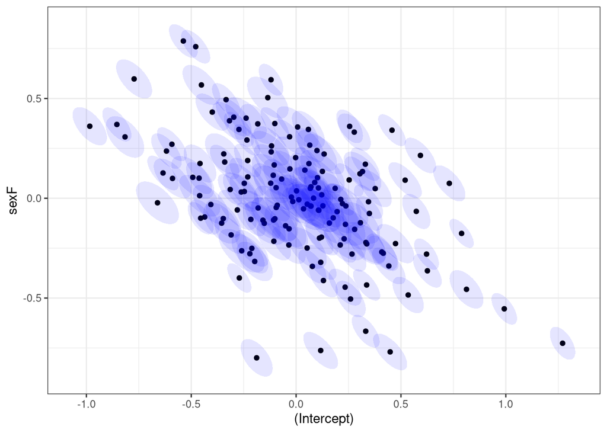

```r
gg0 <- ggplot(rr, aes(x=`(Intercept)`, y = sexF)) + geom_point()
gg0 + geom_polygon(data=ellipse_fun(rr, cvar), aes(x = x, y = y, group = Subject),
                 alpha = 0.1, fill = "blue", colour = NA)
```

The sizes of these ellipses are based on what’s pretty, not on a 95% CI. Here are the 95% CIs (I had to add the vertical (sexF) error bars to convince myself that the ellipse CI calculation was right …

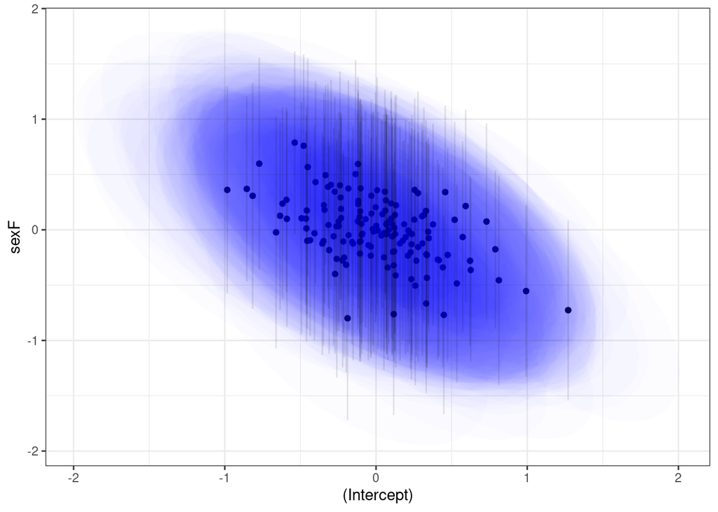

```r
rrt <- tidy(m_red, effects = "ran_vals") |>
    dplyr::select(term, estimate, std.error, level) |>
    pivot_wider(names_from = "term", values_from = c("estimate", "std.error")) |>
    rename(int = "estimate_(Intercept)", sexF = "estimate_sexF", int_sd = "std.error_(Intercept)", sexF_sd = "std.error_sexF")

gg0 + geom_polygon(data=ellipse_fun(rr, cvar, radius = sqrt(qchisq(df=2, 0.95))),
                   aes(x = x, y = y, group = Subject),
                   alpha = 0.01, fill = "blue", colour = NA) +
    geom_linerange(data=rrt, aes(x=int, ymin = sexF - 1.96*sexF_sd, ymax = sexF + 1.96*sexF_sd), alpha = 0.1)
```

Note that our conclusions about the correlation between random slopes and intercepts **depend on the contrasts for the factor** (or in the case of a continuous covariate on the centering/zero point); by default, our two latent variables per group are (intercept) “expected deviation of male attainment from the population mean” and “expected deviation of F-M attainment difference from the population mean”. The observed negative correlation says that schools with lower than average male scores have the females surpassing the males by more than average (upper left corner) and *vice versa*.

If we change to sum-to-zero contrasts (analogous to centering a continuous predictor), the negative correlation disappears (although there is still a negative correlation between the intercept and slope *within* groups).

```r
ss2 <- ScotsSec
contrasts(ss2$sex) <- contr.sum(2)
m_red_contr <- update(m_red, data = ss2)
rr2 <- ranef(m_red_contr)$primary
cvar2 <- attr(rr2, "postVar")
```

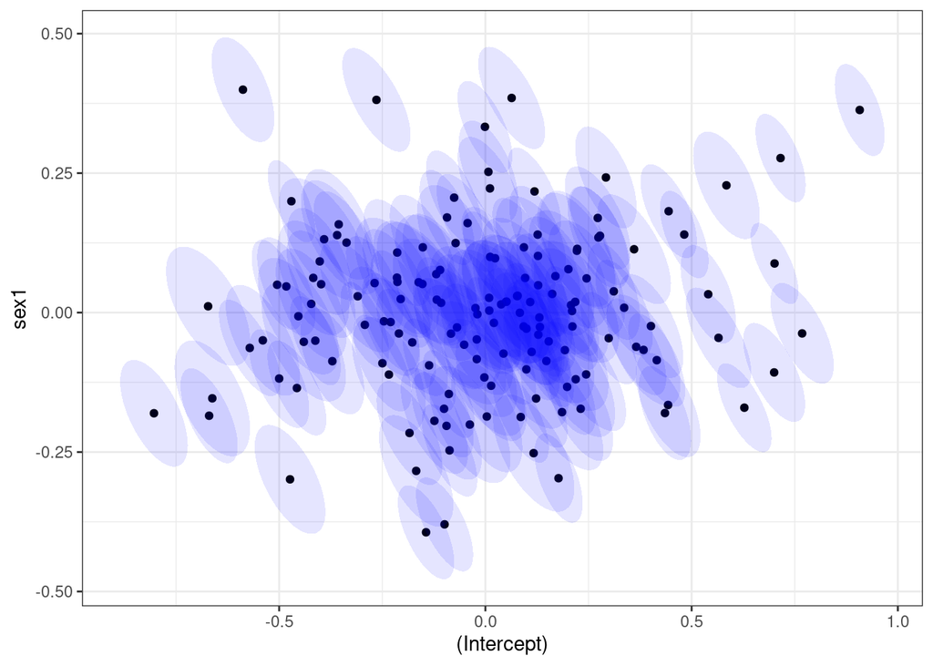

```r
## note that the name of the `sex` parameter has changed (sigh)
ggplot(rr2, aes(x=`(Intercept)`, y = sex1)) + geom_point() +
    geom_polygon(data=ellipse_fun(rr2, cvar), aes(x = x, y = y, group = Subject),
                 alpha = 0.1, fill = "blue", colour = NA)
```